# Comparing Decision Tree and KNN Models on Baseball Dataset

# Introduction

Decision trees are a type of supervised learning algorithm used for predictive modeling. In this analysis, a decision tree model is used to predict the salaries of professional baseball players based on various performance metrics and demographic features. The model follows a “tree-like” structure, where the data is recursively split into smaller subsets based on feature values until it reaches the terminal nodes or leaves, each representing a predicted salary value.

K-Nearest Neighbors (KNN) algorithms classify data points by finding the K closest data points to the query point and making a prediction based on the attributes of those neighbors. The number of neighbors used is variable and can be decided or optimized for. In this regression context, the prediction will be the average of the neighbors’ value (salary).

The dataset includes 263 records of Major League Baseball (MLB) players, collected in 1986, containing multiple features relevant to a player’s performance and their career history.

To perform the analysis, several R packages were utilized for data preprocessing, modeling, and visualization. The `caret`, `FNN` and `rpart` packages supported model development, `ggplot2` and `rpart` were used for creating visualizations, and `knitr` assisted in generating the final report.

# Data description

```r
bb.df <- read.csv("baseball.csv")
bb.df <- na.omit(bb.df)
cat("Data Points:", nrow(bb.df) - sum(is.na(bb.df)))
```

```
## Data Points: 263
```

## Variables

The set contains 263 data points. Our response variable is salary - the player’s annual salary on opening day in 1987 reported in thousands of dollars. Below are descriptions of the features:

- AtBat: # of times at bat in 1986 season
- Hits: # of hits in 1986 season
- HmRun: # of home runs in 1986 season
- Runs: # of runs in 1986 season
- RBI: # of runs batted in in 1986 season
- Walks: # of walks in 1986 season
- PutOuts: # of put outs in 1986 season
- Assists: # of assists in 1986 season
- Errors: # of errors in 1986 season
- Years: # of years of experiences in MLB
- CAtBat: # of times at bat during career
- CHits: # of hits during career
- CHmRun: # of home runs during career
- CRuns: # of runs during career
- CRBI: # of runs batted in during career
- CWalks: # of walks during career
- League: Player’s league at end of 1986 season - {A: American, N: National}
- NewLeague: Player’s league at beginning of 1987 season - {A: American, N: National}
- Division: Player’s division at end of 1986 season - {E: East, W: West}

## Dataset

```r
bb.df$League <- as.factor(bb.df$League)
bb.df$NewLeague <- as.factor(bb.df$NewLeague)
bb.df$Division <- as.factor(bb.df$Division)
head(bb.df, 3)
```

|  | AtBat | Hits | HmRun | Runs | RBI | Walks | Years | CAtBat | CHits | CHmRun | CRuns | CRBI | CWalks | League | Division | PutOuts | Assists | Errors | Salary | NewLeague |
| --- | --- | --- | --- | --- | --- | --- | --- | --- | --- | --- | --- | --- | --- | --- | --- | --- | --- | --- | --- | --- |
| 2 | 315 | 81 | 7 | 24 | 38 | 39 | 14 | 3449 | 835 | 69 | 321 | 414 | 375 | N | W | 632 | 43 | 10 | 475 | N |
| 3 | 479 | 130 | 18 | 66 | 72 | 76 | 3 | 1624 | 457 | 63 | 224 | 266 | 263 | A | W | 880 | 82 | 14 | 480 | A |
| 4 | 496 | 141 | 20 | 65 | 78 | 37 | 11 | 5628 | 1575 | 225 | 828 | 838 | 354 | N | E | 200 | 11 | 3 | 500 | N |

## Encoding Catagorical Variables

We encoded the catagorical variables for KNN down the line.

```r
hold <- bb.df$Salary
dummies <- dummyVars(Salary ~ ., data = bb.df)
bb.df <- as.data.frame(predict(dummies, newdata = bb.df))
bb.df$Salary <- hold
head(bb.df, 3)
```

|  | AtBat | Hits | HmRun | Runs | RBI | Walks | Years | CAtBat | CHits | CHmRun | CRuns | CRBI | CWalks | League.A | League.N | Division.E | Division.W | PutOuts | Assists | Errors | NewLeague.A | NewLeague.N | Salary |
| --- | --- | --- | --- | --- | --- | --- | --- | --- | --- | --- | --- | --- | --- | --- | --- | --- | --- | --- | --- | --- | --- | --- | --- |
| 2 | 315 | 81 | 7 | 24 | 38 | 39 | 14 | 3449 | 835 | 69 | 321 | 414 | 375 | 0 | 1 | 0 | 1 | 632 | 43 | 10 | 0 | 1 | 475 |
| 3 | 479 | 130 | 18 | 66 | 72 | 76 | 3 | 1624 | 457 | 63 | 224 | 266 | 263 | 1 | 0 | 0 | 1 | 880 | 82 | 14 | 1 | 0 | 480 |
| 4 | 496 | 141 | 20 | 65 | 78 | 37 | 11 | 5628 | 1575 | 225 | 828 | 838 | 354 | 0 | 1 | 1 | 0 | 200 | 11 | 3 | 0 | 1 | 500 |

# Exploratory Analysis

## Features

We conducted an exploratory analysis of the numerical features to understand their distributions ahead of creating our decision tree. League, NewLeague, and Division were all excluded since they are catagorical variables.

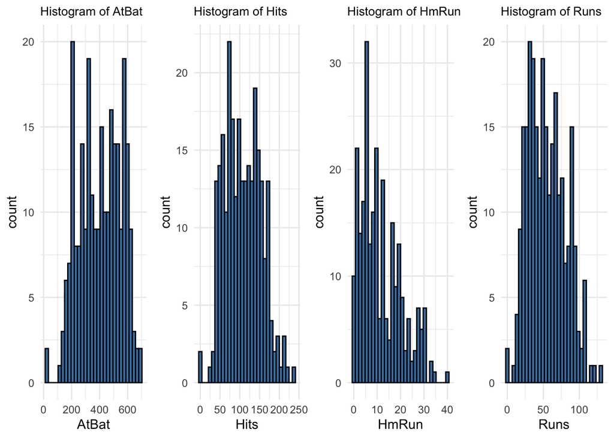

```r
hist_vars <- c("AtBat", "Hits", "HmRun", "Runs", "RBI", "Walks", "PutOuts", "Assists",
               "Errors", "Years", "CAtBat", "CHits", "CHmRun", "CRuns", "CRBI", "CWalks")

plots <- lapply(hist_vars, function(col) {
  ggplot(bb.df, aes_string(x = col)) +
    geom_histogram(fill = "steelblue", color = "black", bins = 30) +
    ggtitle(paste("Histogram of", col)) +
    theme_minimal() +
    theme(plot.title = element_text(size = 10))
})
grid.arrange(grobs = plots[1:4], nrow = 1)
```

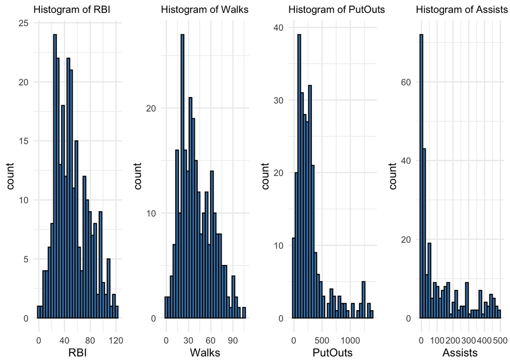

```r
grid.arrange(grobs = plots[5:8], nrow = 1)
```

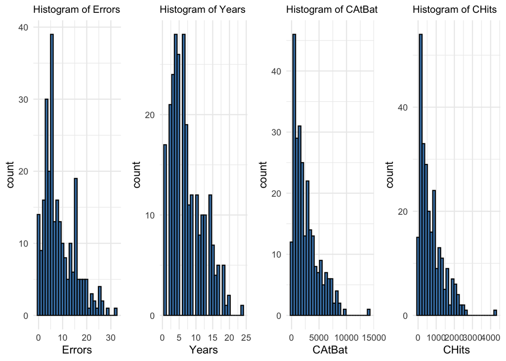

```r
grid.arrange(grobs = plots[9:12], nrow = 1)
```

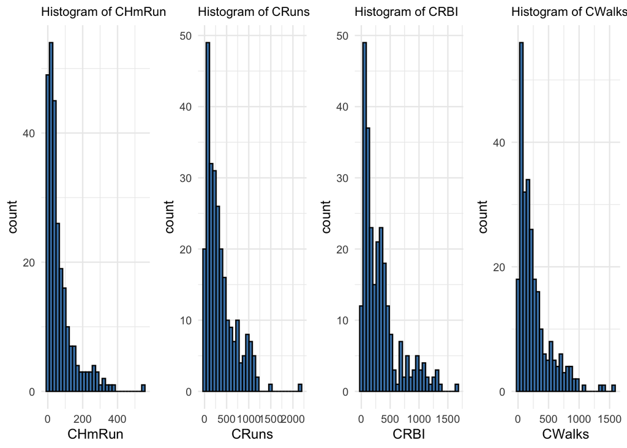

```r
grid.arrange(grobs = plots[13:16], nrow = 1)
```

From the histograms above, we can see that the features that are based on a singular season mostly have a uniform or normal distribution. However, the features based on career performance exhibit a right-skewed distribution.

This may indicate outliers - “superstars” that have had exceptional careers. Season over season these superstars are leading in certain features, which contributes to the player’s career-long related features to be much greater than peers.

We do not believe these outliers will create issues within our model, such superstars should be paid in excess. We do note that features unrelated to performance may impact their wages. For example, a superstar that is a household name and thus sells more jerseys, tickets, etc. may be paid higher than another player despite worse performance in a single season.

## Response Variable

The response variable in this analysis is Salary, which represents the annual salary (in thousands of USD) of Major League Baseball (MLB) players for the 1987 season. To understand the distribution of salaries, we first examined the summary statistics.

```r
summary(bb.df$Salary)
```

```
##    Min. 1st Qu.  Median    Mean 3rd Qu.    Max.
##    67.5   190.0   425.0   535.9   750.0  2460.0
```

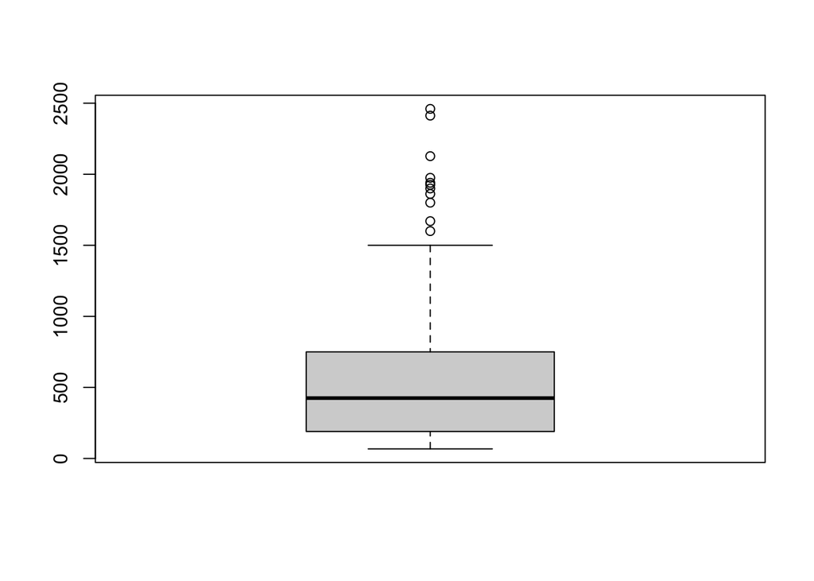

Distribution of Salary.

```r
boxplot(bb.df$Salary)
```

These values indicate that the salary data is right-skewed, with a small number of players earning significantly more than the rest. The median salary is $425,000, while the mean is higher at approximately $535,900, suggesting the presence of high-earning outliers. We see these illustreated in the boxplot where there are serveral outliers making above 1.5 million dollars.

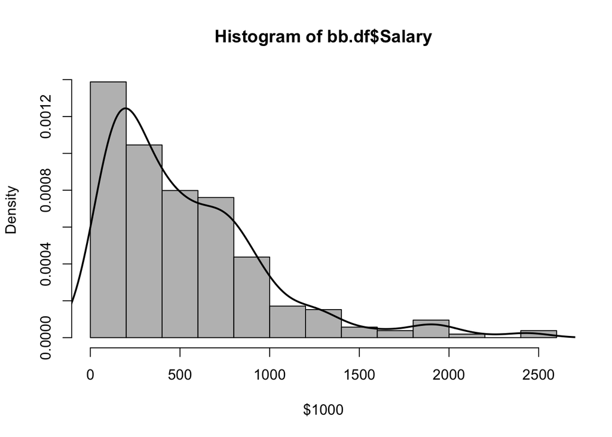

Distribution of Salary.

```r
hist(bb.df$Salary,
 col="gray",
 border="black",
 prob = TRUE,
 xlab = "$1000")
lines(density(bb.df$Salary),
 lwd = 2,
 col = "black")
```

The histogram helps illustrate the overall shape of the distribution, with most players earning between $100,000 and $800,000. These visualizations confirm that salary is not normally distributed and should be treated with care during modeling, especially when considering transformations or assumptions of normality.

# Modelling

To evaluate which model is more effective at predicting professional baseball player salaries, we compare the performance of a Decision Tree model and a K-Nearest Neighbors (KNN) regression model.

## Training and Testing Sets

```r
RNGversion(rand.v)
set.seed(seed.val)
trainIndex <- createDataPartition(bb.df$Salary, p = 0.7, list = FALSE)
train <- bb.df[trainIndex, ]
test  <- bb.df[-trainIndex, ]
```

## Fitting Decision Tree

```r
trctrl <- trainControl(method = "cv", number = 10)

tree <- train(
  Salary ~ .,
  data = train,
  method = "rpart",
  trControl = trctrl,
  tuneLength = 20,
  metric = "RMSE"
)
print(tree)
```

```
## CART
##
## 185 samples
##  22 predictor
##
## No pre-processing
## Resampling: Cross-Validated (10 fold)
## Summary of sample sizes: 166, 166, 166, 167, 167, 167, ...
## Resampling results across tuning parameters:
##
##   cp          RMSE      Rsquared   MAE
##   0.00000000  280.2252  0.6076598  183.6900
##   0.02281621  278.6078  0.5947699  196.9460
##   0.04563242  283.1580  0.5761881  203.6005
##   0.06844862  300.2853  0.5219494  216.6253
##   0.09126483  316.2105  0.4715145  222.4363
##   0.11408104  316.2105  0.4715145  222.4363
##   0.13689725  322.4872  0.4516651  228.8463
##   0.15971345  346.0524  0.3520868  246.7094
##   0.18252966  343.3114  0.3549703  245.2150
##   0.20534587  343.3114  0.3549703  245.2150
##   0.22816208  343.3114  0.3549703  245.2150
##   0.25097828  343.3114  0.3549703  245.2150
##   0.27379449  343.3114  0.3549703  245.2150
##   0.29661070  343.3114  0.3549703  245.2150
##   0.31942691  343.3114  0.3549703  245.2150
##   0.34224311  343.3114  0.3549703  245.2150
##   0.36505932  343.3114  0.3549703  245.2150
##   0.38787553  343.3114  0.3549703  245.2150
##   0.41069174  343.3114  0.3549703  245.2150
##   0.43350795  395.2850  0.2892283  305.0767
##
## RMSE was used to select the optimal model using the smallest value.
## The final value used for the model was cp = 0.02281621.
```

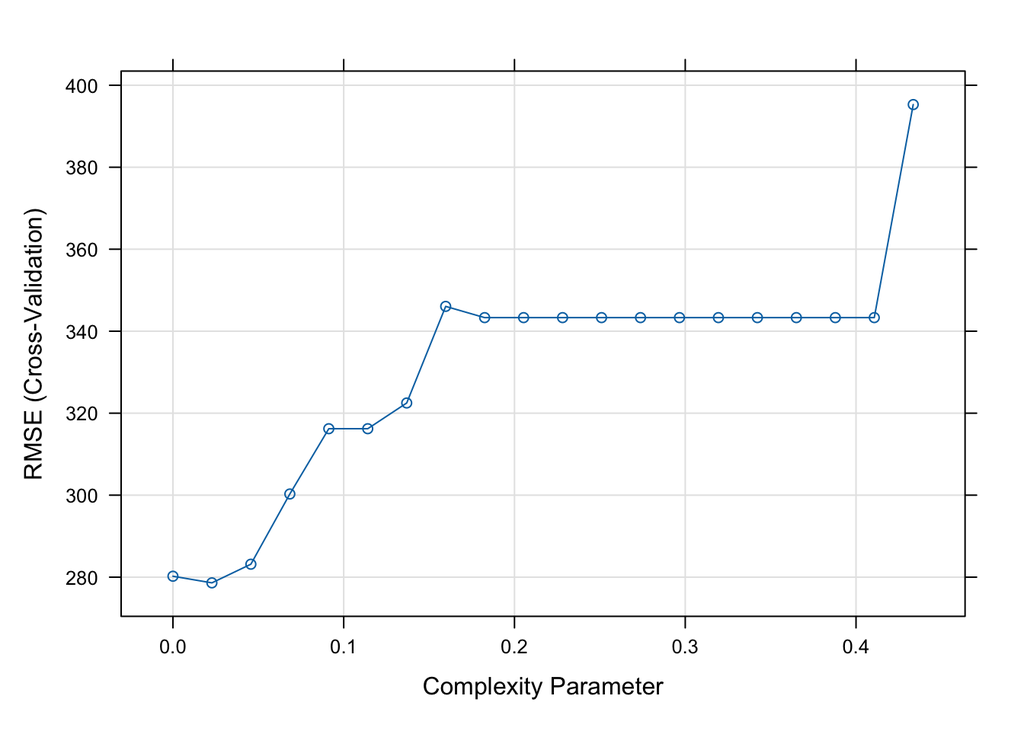

```r
plot(tree)
```

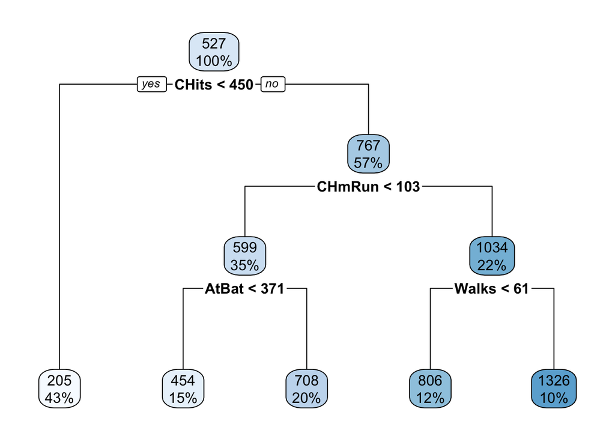

```r
rpart.plot(tree$finalModel)
```

The decision tree has 5 terminal or leaf nodes as shown in the graph above.